# Chapter 3 - Count-Based VPAs (Density Independent Models)

Mairin Deith

=====

# Chapter 3 summary

Chapter 3 of Morris and Doak’s book demonstrates how temporal stochasticity can influence our ability to predict future population sizes. `N` is log-normally distributed because $N_t$ is the resuilt of multiple products of $N_{t-1}$ and $\lambda$ - *results from the central limit theorem*

As time continues, the standard distribution of our estimate of $N_t$ (log-transformed).
$$N_{t+1} = N_0 (\lambda_0 \lambda1, ... , \lambda_t)$$
therefore
$$\lambda_G = (\lambda_0 \lambda_1, ..., )^{1/t}$$
and if
$$\mu=log \lambda_G \approx \frac{\Sigma^t_{i=1} (\lambda_i)}{t}$$
If $\mu > 0, \lambda_G > 1$, the population will generally increase. If $\mu < 0, \lambda_G < 1$

$log \lambda_G$’ follows a normal distribution $N(\mu, \sigma^2)$. As $\sigma^2$ increases, so does the range of possible futures.

It’s possible to calculate extinction risk by calculating probability species hits quasi-extinction at points between $t_0$ to $t_n$. This follows a **diffusion approximation**: there is an absorbing lower boundary, and as time passes the diffusive movement of particles continues to move upwards in a growing, more variable cloud.

### Assumptions of the diffusion approx:

1. No catastrophes/bonanzas, environmental perturbations are small to moderate
2. Change in N is temporally independent - no temporal autocorrelation

$\mu$ is the overall rate of rise/sink of the population, $\sigma$ is the rate of random diffusion.

The probability of hitting the quasi-extinction threshold follows described by an inverse Gaussian distribution.
$$g (t | \mu \sigma^2 d) = \frac{d}{\sqrt{2 \pi \sigma^2 t^3}} exp(\frac{-(d+ \mu t)^2}{2 \sigma^2 t})$$
Where $d$ is $log N_c - log N_x$ or `log(current population size) - log(quasi-extinction threshold)`.

When $\mu$ is positive, there is less area under the quasi-extinction curve. As $\sigma^2$ increases or $\mu$ decreases, the QE time decreases.

Integrating from $t_0$ to $t_x$ provides a cumulative probability distribution:

$$G(T | d, \mu, \sigma^2) = \Phi(\frac{-d-\mu T}{\sqrt{\sigma^2 T}}) + exp(\frac{-2 \mu d}{\sigma^2}) \Phi(\frac{-d+\mu T}{\sqrt{\sigma^2 T}})$$
where $\Phi$ is the standard normal cumulative probability distribution.

Morris and Doak then describe how we can make qualitative assessments of population trajectories with $\mu$ and $\sigma^2$.

$\mu$ can be calculated with:
$$\hat{\mu} = \frac{1}{q} \Sigma^{q-1}_{i=0} log(N_{i+1}/N_i)$$

$\sigma$ can be calculated with:
$$\hat{\sigma^2} = \frac{1}{q-1} \Sigma^{q-1}_{i=0} (log(N_{i+1}/N_i)-\hat{\mu})^2$$

```r
adultBearsF <- data.frame(census=1:39, year=1959:1997, females=c(44.0,47.0,46,44,46,45,46,40,39,39,42,39,41,40,33,36,34,39,35,34,38,36,37,41,39,51,47,57,48,60,65,74,69,65,57,70,81,99,99))
adultBearsF$logF <- c(log((adultBearsF$females[-1]*1.0)/(1.0*adultBearsF$females[1:(nrow(adultBearsF)-1)])),NaN)

mu.est.short <- mean(adultBearsF$logF, na.rm = T)
sigma.est.short <- (1/38)*sum((adultBearsF$logF[1:38]-mu.est.short)^2)

mu.est.short; sigma.est.short
```

```
## [1] 0.02134027
```

```
## [1] 0.01270747
```

But the linear regression method is more reliable than a simple sum - it places confidence limits on parameters and estimates PVA assumptions.

There is a caveat - *the 1 assumption of linear regression is equal variance over time*. In reality, we expect variance to increase in time because we are applying a diffusion approximation so variation in population change is non-uniform.

If 2 censuses are separated by $t_{i+1}-t_i$, $log(N_{t+1}/N_i)$ has a variance of $\sigma^2(t_{i+1}-t_i)$.

We can first standardize by dividing observations by the time interval, so that $x_i = \sqrt{t_{t+1} - t_i}$

```r
adultBearsF$x <- c(0,sqrt(adultBearsF$census[2:39]-adultBearsF$census[1:38]))
```

Our dependent variable is also transformed:

```r
adultBearsF$y <- adultBearsF$logF/adultBearsF$x
```

And fit the model:

```r
linear.regression <- lm(data=adultBearsF[2:39,], y~0+x) # 0+x ensures that our intercept is fixed at zero

sm <- summary(linear.regression)
mu.est <- sm$coefficients
sm
```

```
##
## Call:
## lm(formula = y ~ 0 + x, data = adultBearsF[2:39, ])
##
## Residuals:
##      Min       1Q   Median       3Q      Max
## -0.21251 -0.07729 -0.02013  0.08252  0.24813
##
## Coefficients:
##   Estimate Std. Error t value Pr(>|t|)
## x  0.02013    0.01900    1.06    0.296
##
## Residual standard error: 0.1156 on 36 degrees of freedom
##   (1 observation deleted due to missingness)
## Multiple R-squared:  0.03025,    Adjusted R-squared:  0.003313
## F-statistic: 1.123 on 1 and 36 DF,  p-value: 0.2963
```

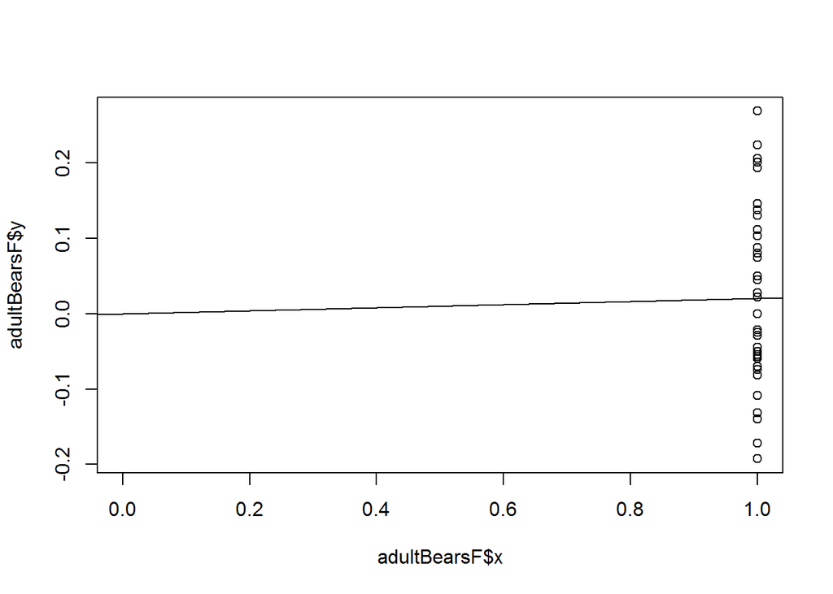

```r
plot(adultBearsF$y~adultBearsF$x); abline(linear.regression)
```

Our estimate of $\mu=0.02013$ isn’t too far off from M+D’s 0.021337. What about $sigma^2$?

```r
sig.est <- mean(sm$residuals^2)
sig.est
```

```
## [1] 0.01299566
```

This is our residual mean square error. To find 95% confidence intervals for $\mu$:

```r
confint(linear.regression, 'x', level=0.95)
```

```
##        2.5 %     97.5 %
## x -0.0183989 0.05866767
```

Again, similar but not identical to the results from M+D. We need to also calculate a confidence interval for $\sigma^2$:

```r
lower.chi <- qchisq(.025, df=37)
upper.chi <- qchisq(.975, df=37)

lower.chi; upper.chi
```

```
## [1] 22.10563
```

```
## [1] 55.66797
```

```r
upper.sigma <- 37*sig.est/upper.chi
lower.sigma <- 37*sig.est/lower.chi

upper.sigma; lower.sigma
```

```
## [1] 0.008637632
```

```
## [1] 0.0217519
```

The Durbin-Watson test for autocorrelation of residuals can be used to test an assumption of the model: that changes in `logN` are not autocorrealted. This can be done in R with the `dwtest` from the `lmtest` package.

```r
library(lmtest)
dwtest(linear.regression)
```

[output not shown]

To assess the presence of outliers, we can look at Cook’s distance graphically:

```r
library(olsrr)
```

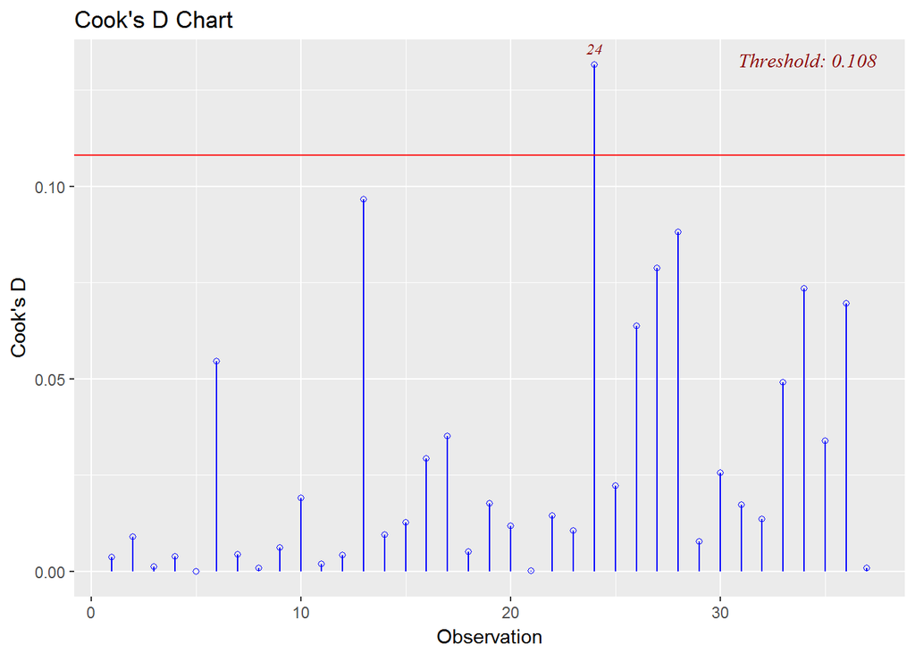

```r
ols_plot_cooksd_chart(linear.regression)
```

Or studentized residuals:

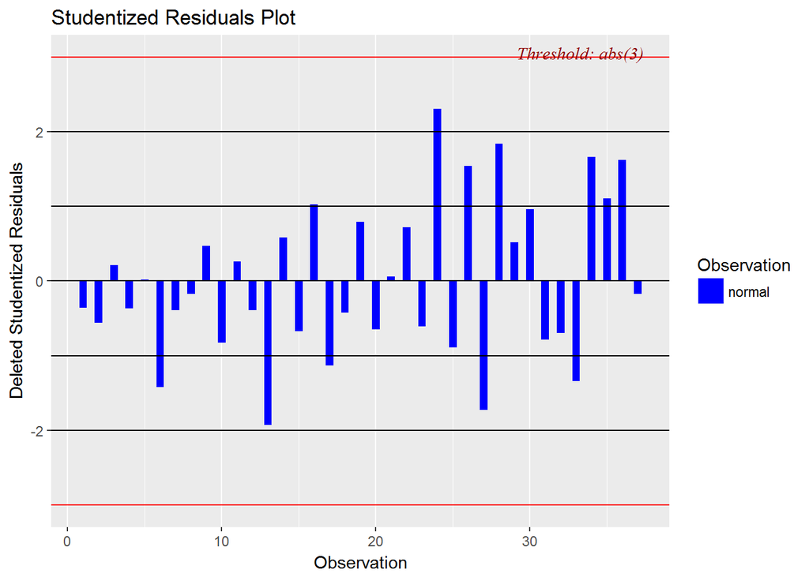

```r
ols_plot_resid_stud(linear.regression)
```

To compare before- and after-fire population dynamics:

```r
before.fire <- adultBearsF[which(adultBearsF$year < 1988),]
after.fire <- adultBearsF[which(adultBearsF$year >= 1988),]
```

```r
before.lm <- lm(data=before.fire[2:nrow(before.fire),], y~0+x) # 0+x ensures that our intercept is fixed at zero
after.lm <- lm(data=after.fire[2:nrow(after.fire),], y~0+x) # 0+x ensures that our intercept is fixed at zero
before.sigma.est <- mean(summary(before.lm)$residuals^2)
after.sigma.est <- mean(summary(after.lm)$residuals^2)

before.sigma.est; after.sigma.est
```

```
## [1] 0.0121785
```

```
## [1] 0.0155222
```

```r
var.test(after.lm, before.lm)
```

```
##
##  F test to compare two variances
##
## data:  after.lm and before.lm
## F = 1.4046, num df = 7, denom df = 27, p-value = 0.4882
## alternative hypothesis: true ratio of variances is not equal to 1
## 95 percent confidence interval:
##  0.5012689 6.1604764
## sample estimates:
## ratio of variances
##           1.404615
```

We cannot reject the null hypothesis that the true ratio of variances=1. Now to do the same with $\mu$:

```r
adultBearsF$x.before <- c(before.fire$x, rep(0,nrow(adultBearsF)-nrow(before.fire)))
adultBearsF$x.after <- c(rep(0,nrow(adultBearsF)-nrow(after.fire)),after.fire$x)
```

```r
mu.fires <- lm(data=adultBearsF[2:39,], y~0+x.before+x.after)
# mu.after <- lm(data=adultBearsF[2:39,], y~0+x.after)

mu.fires$coefficients
```

```
##   x.before    x.after
## 0.00872132 0.05564170
```

There is some difference in $/mu$ before and after the fire. Is it significantly different?

```r
t <- (mu.fires$coefficients[2]-mu.fires$coefficients[1])/
  sqrt(sig.est*((1/29) + 1/(38-29)))
t
```

```
##  x.after
## 1.078675
```

### Using $\mu$ and $\sigma$ estimates to calculate probability of extinction

We can use a cumulative density function to create a CDF of extinction. I will copy the MATLAB code into functions to use in R:

```r
library(VGAM)
# Fortunately there's an erf function in VGAM!

stdnormcdf <- function(z){
  # Calculates the standard normal cumulative dist
  #    function.
  phi=0.5*(1+erf(z/sqrt(2)))
  return(phi)
}

extcdf <- function(mu, sig2, d, tmax){
  # Calculates the standard normal cumulativedist
  #    function from t=0 to tmax
  # d is log distance from the quasi-extinction
  #    threshold
  # Requires extcdf

  g <- vector(length=tmax)
  for(t in 1:tmax){
    g[t] <- stdnormcdf((-d-mu*t)/sqrt(sig2*t))+
      exp(-2*mu*d/sig2)*stdnormcdf((-d+mu*t)/sqrt(sig2*t))
  }
  return(g)
}

gammarv <- function(alpha, beta, n){
  # Generates a vector of n random numbers from the
  #   Gamma(alpha,beta) distribution
  gamma <- vector()
  for(i in 1:n){
    X=0
    k=floor(alpha)
    g=alpha-k
    if(k>0){
      X=-log(prod(runif(n=k)))
    }
    if(g==0){
      gamma=c(gamma, beta*X)
    } else {
      a=g
      b=1-g
      y=1
      z=1
      while((y+z)>1){
        y=runif(1)^(1/a)
        z=runif(1)^(1/b)
      }
      Y=y/(y+z) # Y is a Beta(g, 1-g) random variable
      Z=-log(runif(1)) # Z is a Gamma random var
      gamma=c(gamma, beta*(X*Y*Z))
    }
  }
  return(gamma)
}

betarn <- function(m,v,n){
  # Generates a row vector of length n, the elements of which
  #   are Beta random variables with mean (m) variance (v)
  if(v==0){
    beta=rep(1,n)
  } else if(v>=(m*(1-m))){
    stop('ERROR:\n   Variance of Beta too large given the mean!\n\n')
  } else {
    a=m*(m*(1-m)/v-1)
    b=(1-m)*(m*(1-m)/v-1)
    beta=vector()
    for(i in 1:n){
      k1=floor(a)
      k2=floor(b)
      if(k1==0 & k2==0){
        Y=1
        Z=1
        while((Y+Z)>1){
          Y=runif(1)^(1/a)
          Z=runif(1)^(1/b)
        }
      } else {
        Y=gammarv(a,1,1)
        Z=gammarv(b,1,1)
      }
    beta=c(beta, Y/(Y+Z))
    }
  }
  return(beta)
}

chi2rv <- function(df){
  # Generates a chi-squared random number, df = degrees of freedom
  if(magrittr::mod(df,2)==0){
    x=-2*log(prod(runif(1,df/2)))
  } else {
    k=(df/2)-0.5
    v=sum(-log(runif(n=k)))
    y=betarn(0.5, 0.124, 1)
    z=-log(runif(1))
    x=2*(v+y*z)
  }
  return(x)
}
```

`extcdf` returns a column with `tmax` rows containing probabilities that the extinction threshold will be reached by each future time.

Unlike estimates of $\mu$ and $\sigma^2$, we cannot calculate confidence intervals - have to use **parametric bootstrapping**. Non-parametric bootstrapping is when you bootstrap from the existing data (i,e, constructing a set of *q* values randomly chosen from the observed log population growth rates, then calculating $\mu$ and $\sigma^2$, as well as $\hat{G}$ when $\mu$ and $\sigma^2$ are in their confidence limits).

We will use $N_c = 99$, $N_x=20$, and parameters from above in our bootstrapping procedure:

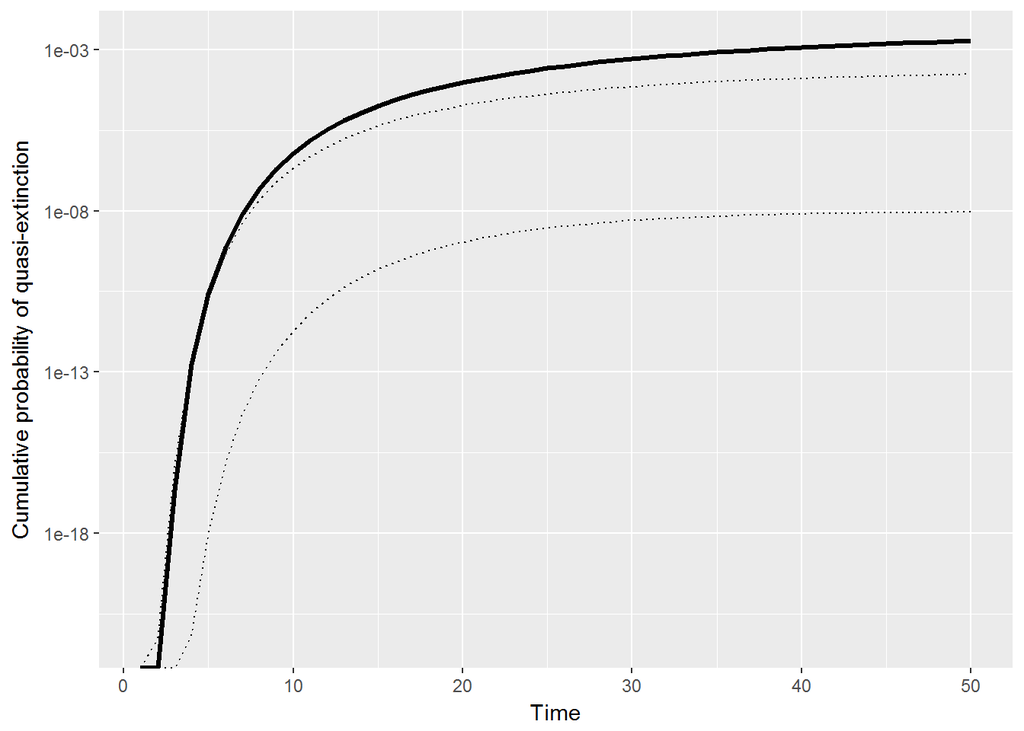

```r
library(ggplot2)
mu <- 0.02134 # Use the M+D values here
sig2 <- 0.01305
CI_mu <- c(-0.01621, 0.05889)
CI_sig2 <- c(0.00867, 0.02184)
q <- 38    # Enter the number of transitions in dataset
tq <- 30   # Length of the census (in years)
Nc <- 99   # Current pop size
Ne <- 20   # Enter the quasi-extinction threshold
tmax <- 50 # Maximum year

Nboot <- 500 # Number of bootstrap samples for calculating conf ints

d <- log(Nc/Ne)
SEmu <- sqrt(sig2/tq)
Glo <- rep(1, tmax) # stores ones as upper extn probabilities
Gup <- rep(0, tmax) # store zeros as lower extinction probabilities

set.seed(12345)

Gbest <- extcdf(mu, sig2, d, tmax)

parboot_res <- data.frame('t'=1:tmax, 'G.best'=Gbest, 'G.upper'=rep(NaN,tmax), 'G.lower'=rep(NaN,tmax))

for(i in 1:Nboot){
  murnd <- Inf
  while(murnd < CI_mu[1] | murnd > CI_mu[2]){
    murnd <- mu+SEmu*rnorm(1)
  }
  sig2rnd <- Inf
  while((sig2rnd < CI_sig2[1] | sig2rnd > CI_sig2[2])==T){
    sig2rnd <- sig2*chi2rv(q-1)/(q-1)
  }

  G <- extcdf(murnd, sig2rnd, d, tmax)

  for(t in 1:tmax){
    if(G[t] > Glo[t]){
      Gup[t] <- G[t]
    }
    if(G[t] < Glo[t]){
      Glo[t] <- G[t]
    }
  }
}

parboot_res$G.upper <- Glo
parboot_res$G.lower <- Gup

# Create a dataframe for plotting
ggplot(parboot_res, aes(x=t)) +
  geom_line(aes(y=G.best), size=1.2)+
  geom_line(aes(y=G.upper), linetype="dotted")+
  geom_line(aes(y=G.lower), linetype="dotted") +
  # Don't forget that the y-axis is log-scale
  scale_y_log10()+
  xlab('Time') +
  ylab('Cumulative probability of quasi-extinction')
```

## Assumptions of simple count-based PVAs

Keep in mind that these assumptions are not weaknesses of the model - making the assumptions explicit is an advantage of the quantitative approaches to population viability rather than an approach based on intuition or natural history knowledge. We can often determine whether violations of these assumptions are going to render our estimates of viability pessimistic or optimistic and adjust our interpretation accordingly.

1. Both $\mu$ and $\sigma^2$ are constant over time - this can occur as a result of density dependence, demographic stochasticity, and temporal trends in environment. Can be tested by regressing $log(N_t/N_t)$ by $N_t$ (to test for density dependence) or year (to test for temporal trends). Changes in $\sigma^2$ can be tested for by calculating squared deviation of $log(N_{t+1}/N_t)$ and the constant $\mu$ or yearly $\mu_t$.
2. No environmental autocorrelation - the diffusion approximation and the regression used to calculate $\mu$ and $\simga^2$ assume that population growth rates over different time intervals are independent, having a common mean and variatnce but no tendency for adjacent $\lambda_t$s to be more similar to one another. Can test with autocorrelation tests (e.g. Durbin-Watson *t* statistic)
3. No catastrophes or bonanzas - the diffusion approximation assumes incremental changes over incremental time steps, no giant leaps/bounds
4. No observation error - all error observed in the population growth rates via censuses must have arisen from variation in the population growth rate i.e., it must be genuine variation and not a function of observer error. This can cause **more pessimistic** estimates beicause it will introduce artificial variation in the population. The magnitude of observation error can be assessed by repeated sampling of the same area and “ground-truthing” indirect measures of abundance. Some species introduce a form of observation error by their life-history traits (e.g. species that leave a dormant seed bank can have an observed population size of zero even though there are living individuals dormant underground).

Simple PVAs are still useful in cases when we want a simple measure and are aware of the effects of the model assumptions. It’s useful if we want to compare to another population or species who has experienced, when you want to know the general direction of the trend - i.e. positive or negative - when your data are limited. **Accurate models require accurate and more data**.

Generally, you need **at least 10 censuses for this method**, and it can provide reliable estimates of direction and sign of $\mu$ and relative rankings.